# Production agricole mondiale

Ewen Lecoeur, Alice Sartre, Arthur Payen

2023-11-23

# Projet de Statistiques : Production agricole mondiale

# Sources :

http://www.fao.org/home/en/ https://data.worldbank.org/ https://www.kaggle.com/datasets/patelris/crop-yield-prediction-dataset, Richi Patel, *Crop Yield Prediction Dataset (2021)*

# Préparation des données et packages

```r
rm(list=ls())
library(knitr)
library(ggplot2)
library(cowplot)
library(FactoMineR)
library(factoextra)
library(corrplot)
library(ppcor)
library(emmeans)
library(car)
library(plyr)
```

```r
agri = read.table("Yield.csv")
head(agri)
```

```
##      Area        Item Year yield rain pest  temp
## 1 Albania       Maize 1990 36613 1485  121 16.37
## 2 Albania    Potatoes 1990 66667 1485  121 16.37
## 3 Albania Rice, paddy 1990 23333 1485  121 16.37
## 4 Albania     Sorghum 1990 12500 1485  121 16.37
## 5 Albania    Soybeans 1990  7000 1485  121 16.37
## 6 Albania       Wheat 1990 30197 1485  121 16.37
```

```r
agripays = read.table("Yieldbycountry.csv")
head(agripays)
```

```
##      Area Year average_rain_fall_mm_per_year pesticides_tonnes avg_temp Maize
## 1 Albania 1990                          1485               121    16.37 36613
## 2 Albania 1991                          1485               121    15.36 29068
## 3 Albania 1992                          1485               121    16.06 24876
## 4 Albania 1993                          1485               121    16.05 24185
## 5 Albania 1994                          1485               201    16.96 25848
## 6 Albania 1995                          1485               251    15.67 31300
##   Potatoes Rice..paddy Sorghum Soybeans Wheat Cassava Sweet.potatoes
## 1    66667       23333   12500     7000 30197      NA             NA
## 2    77818       28538    6667     6066 20698      NA             NA
## 3    82920       40000    3747     4507 24388      NA             NA
## 4    98446       41786      NA     7998 29976      NA             NA
## 5    81404          NA      NA     7927 24745      NA             NA
## 6   111323          NA      NA    11791 28703      NA             NA
##   Plantains.and.others Yams
## 1                   NA   NA
## 2                   NA   NA
## 3                   NA   NA
## 4                   NA   NA
## 5                   NA   NA
## 6                   NA   NA
```

# Questions à se poser :

- Décrire le jeu de données (stats descritptives) → voir des éventuelles corrélations entre des variables ? → graphes de corrélation (correlation plot)
- ACP pour sortir des classes de pays ou des classes de productions (par rendement, ou par climat = couple précipitations/température, ou par production principale)
- ACP pour le rendement (pour voir quel facteur influence le plus cette variable)
- essayer d’expliquer les rendements des différentes années par des facteurs (précipitations, températures, intrants) → évolution annuelle des rendements à comparer avec les évolutions annuelles des facteurs de production ? quel facteur de production est le plus important ? étude à l’échelle de chaque pays ? ou bien à l’échelle mondiale ?
- rendement mondial = f(année) → pour chaque production ?
- rendement/pays = f(température, pluie)
- rendement/pays = f(pesticides)
- quantité de pesticides = f(pays)

# Un peu de statistiques descriptives…

```r
sommaire = summary(agri)
kable(sommaire)
```

|  | Area | Item | Year | yield | rain | pest | temp |
| --- | --- | --- | --- | --- | --- | --- | --- |
|  | Length:13130 | Length:13130 | Min. :1990 | Min. : 50 | Min. : 51 | Min. : 0.0 | Min. : 1.30 |
|  | Class :character | Class :character | 1st Qu.:1995 | 1st Qu.: 18000 | 1st Qu.: 608 | 1st Qu.: 264.5 | 1st Qu.:16.23 |
|  | Mode :character | Mode :character | Median :2001 | Median : 39544 | Median :1083 | Median : 2172.2 | Median :20.86 |
|  | NA | NA | Mean :2002 | Mean : 70969 | Mean :1157 | Mean : 14838.7 | Mean :19.97 |
|  | NA | NA | 3rd Qu.:2008 | 3rd Qu.: 97152 | 3rd Qu.:1651 | 3rd Qu.: 13335.2 | 3rd Qu.:25.87 |
|  | NA | NA | Max. :2013 | Max. :501412 | Max. :3240 | Max. :367778.0 | Max. :30.42 |

```r
str(agri)
```

```
## 'data.frame':    13130 obs. of  7 variables:
##  $ Area : chr  "Albania" "Albania" "Albania" "Albania" ...
##  $ Item : chr  "Maize" "Potatoes" "Rice, paddy" "Sorghum" ...
##  $ Year : int  1990 1990 1990 1990 1990 1990 1991 1991 1991 1991 ...
##  $ yield: int  36613 66667 23333 12500 7000 30197 29068 77818 28538 6667 ...
##  $ rain : int  1485 1485 1485 1485 1485 1485 1485 1485 1485 1485 ...
##  $ pest : num  121 121 121 121 121 121 121 121 121 121 ...
##  $ temp : num  16.4 16.4 16.4 16.4 16.4 ...
```

Dans cette partie, nous allons essayer d’observer de éventuels liens entre les rendements agricoles des pays et les facteurs qui les caractérisent.

# … Puis une analyse plus en profondeur

On peut commencer par une analyse des facteurs de production des facteurs abiotiques (précipitations et températures) sur lesquels on ne peut pas jouer par exemple :

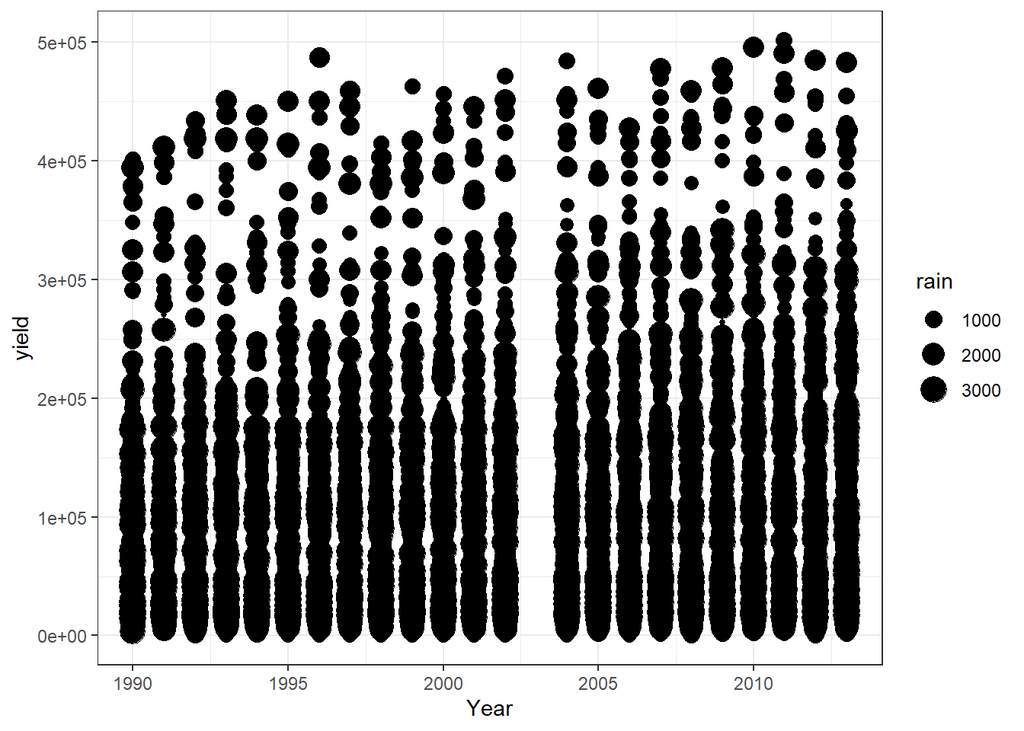

```r
ggplot(agri, aes(x=Year, y=yield)) + theme_bw() + geom_point(aes(y=yield,size=rain))
```

De plus, dans notre jeu de données, on ne dispose que de la quantité de pesticides totale pour chaque année et par pays. On peut donc se demander s’il n’y a pas des cultures qui réagissent mieux à l’utilisation de pesticides que d’autres, ce qui est une question possiblement intéressante à se poser pour les pays afin d’orienter leur politique agricole.

Tout d’abord, on peut commencer par un graphique représentant le rendement en fonction de l’utilisation de pesticides, pour essayer de dégager des groupes de cultures qui réagissent éventuellement mieux à l’utilisation de pesticides.